# WITM

2024-08-14

#ANALYSIS - SECTION 2

```r
# OPEN CSV file
witm <- read.csv2("Data/WITM_csv_last.csv")

source(file="WITM_variables.R")

print(date())
```

```
## [1] "Wed Aug 14 08:06:48 2024"
```

**-.-.-.-.-.-.-.-.-.-.-.-.-.-.-.-.-.-.-.-.-.-.-.-.-.-.-.-.-.-** Section 2: Financial Status

Q10. What was the annual budget for your group, organization and/or movement in each of the following years in $USD?

Annual_budget

Percentage_2021

Percentage_2022

Percentage_2023

1. Zero budget

15.2

12.9

11.2

2. <5000

17.9

15.4

14.8

3. 5001-10000

12.3

13.0

11.5

4. 10001-30000

13.5

14.9

15.5

5. 30001 -50000

8.7

7.8

8.7

6. 50001 - 100000

8.9

11.2

12.4

7. 100001 - 250000

10.8

10.7

11.2

8. 250001 - 500000

5.2

5.7

6.0

1. 500001 - 1000000

2.9

3.3

3.4

10. 1000001 - 2000000

1.7

1.9

2.0

11. 2000001 - 4000000

0.9

1.2

1.2

12. > 4000001

2.1

2.1

2.0

**-.-.-.-.-.-.-.-.-.-.-.-.-.-.-.-.-.-.-.-.-.-.-.-.-.-.-.-.-.-**

**BUDGET GROUPED PROPOSAL**

```
## # A tibble: 13 × 2
##    q10_budget_year_2021      n
##    <chr>                 <int>
##  1 (a) Zero budget         135
##  2 (b) <5000               159
##  3 (c) 5001-10000          109
##  4 (d) 10001-30000         120
##  5 (e) 30001 -50000         77
##  6 (f) 50001 - 100000       79
##  7 (g) 100001 - 250000      96
##  8 (h) 250001 - 500000      46
##  9 (i) 500001 - 1000000     26
## 10 (j) 1000001 - 2000000    15
## 11 (k) 2000001 - 4000000     8
## 12 (l) > 4000001            19
## 13 <NA>                    102
```

```
## # A tibble: 8 × 4
##   Annual_budget       Percentage_2021 Percentage_2022 Percentage_2023
##   <chr>                         <dbl>           <dbl>           <dbl>
## 1 (a) Zero budget                15.2            12.9            11.2
## 2 (b) <5000                      17.9            15.4            14.8
## 3 (c) 5001-10000                 12.3            13              11.5
## 4 (d) 10001-30000                13.5            14.9            15.5
## 5 (e) 30001 -50000                8.7             7.8             8.7
## 6 (f) 50001 - 100000              8.9            11.2            12.4
## 7 (g) 100001 - 250000            10.8            10.7            11.2
## 8 (h) > 250001                   12.8            14.2            14.6
```

**–Lecture ———————————————————————–**

This grouping maintains interesting proportions respecting the way the question was asked. Only the highest amounts are grouped together.

We suggest using the year 2023 as a crossover variable for other questions as it accounts for size.

**————————————————————————————————**

**-.-.-.-.-.-.-.-.-.-.-.-.-.-.-.-.-.-.-.-.-.-.-.-.-.-.-.-.-.-**

Q11. In 2020 (during COVID-19 pandemic), how was your budget affected?

| q11_covid_incidence | n | Percentage |
| --- | --- | --- |
| 1 Grow substantively | 47 | 6.2 |
| 2 Grow slightly | 157 | 20.6 |
| 3 Stay the same | 155 | 20.3 |
| 4 Decrease slightly | 182 | 23.9 |
| 5 Decrease substantially | 221 | 29.0 |

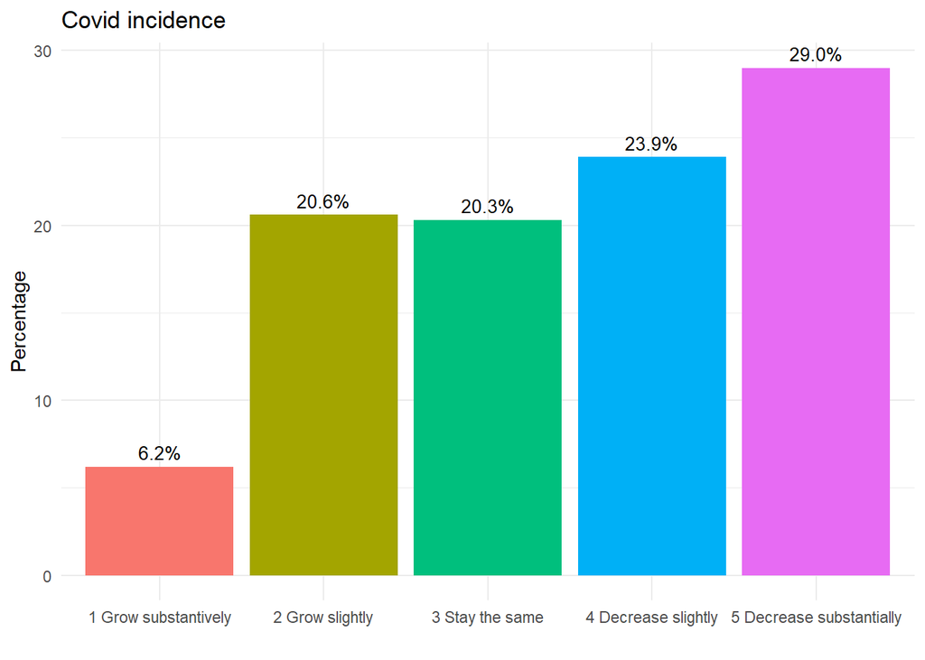

**-.-.-.-.-.-.-.-.-.-.-.-.-.-.-.-.-.-.-.-.-.-.-.-.-.-.-.-.-.-**

##CROSSTABS Q10 - only 2023

**-.-.-.-.-.-.-.-.-.-.-.-.-.-.-.-.-.-.-.-.-.-.-.-.-.-.-.-.-.-**

**2023 budget BY AWID FOCUS SUBJECTS**

(first option)

q4_grouped

1. Zero budget
2. <5000
3. 5001-10000
4. 10001-30000
5. 30001 -50000
6. 50001 - 100000
7. 100001 - 250000
8. > 250001

Anti Caste

6.3

4.1

6.1

3.2

1.2

0.8

NA

2.8

Anti-militarization and peace

13.5

10.9

11.4

10.4

9.3

4.1

4.5

11.7

Climate and environmental justice

33.3

31.3

35.1

33.8

33.7

35.0

27.0

29.0

Countering anti-gender and anti-rights

20.7

25.9

24.6

18.8

18.6

18.7

19.8

37.9

Holistic safety, protection and collective care

20.7

19.0

22.8

17.5

15.1

28.5

18.9

25.5

Lesbian, Bisexual and queer rights

24.3

23.8

23.7

26.6

26.7

24.4

22.5

27.6

Sex workers rights

28.8

25.9

14.9

23.4

23.3

22.8

17.1

16.6

Trans and non-binary rights

16.2

21.1

20.2

18.2

17.4

18.7

17.1

22.1

Other feminists subjects (not AWID focus)

30.6

28.6

28.9

28.6

23.3

26.0

36.0

32.4

**–Lecture———————————————————————–**

Here we can analyze for the organizations according to their budget, in which issues they work or are more represented.

For example, among the organizations with Zero budget there is a higher proportion of those working on Sex workers rights issues than among the organizations with more funding.

**————————————————————————————————**

**AWID FOCUS SUBJECTS BY 2023 budget**

This is the reverse crossover: we see how the amount of the budget is distributed within each of the groups. Remember that the topics overlap.

[output not shown]

q4_grouped

1. Zero budget
2. <5000
3. 5001-10000
4. 10001-30000
5. 30001 -50000
6. 50001 - 100000
7. 100001 - 250000
8. > 250001

Anti Caste

22.6

19.4

22.6

16.1

3.2

3.2

NA

12.9

Anti-militarization and peace

15.8

16.8

13.7

16.8

8.4

5.3

5.3

17.9

Climate and environmental justice

11.6

14.4

12.5

16.3

9.1

13.5

9.4

13.2

Countering anti-gender and anti-rights

9.8

16.2

12.0

12.4

6.8

9.8

9.4

23.5

Holistic safety, protection and collective care

11.0

13.3

12.4

12.9

6.2

16.7

10.0

17.6

Lesbian, Bisexual and queer rights

10.9

14.1

10.9

16.5

9.3

12.1

10.1

16.1

Sex workers rights

15.0

17.8

7.9

16.8

9.3

13.1

8.9

11.2

Trans and non-binary rights

9.5

16.4

12.2

14.8

7.9

12.2

10.1

16.9

Other feminists subjects (not AWID focus)

11.6

14.4

11.3

15.1

6.8

11.0

13.7

16.1

**–Lecture———————————————————————–**

In this case, the distribution is reversed. For each of the work topics, we can see how the Budget is for the organizations that work on these topics.

**————————————————————————————————**

**-.-.-.-.-.-.-.-.-.-.-.-.-.-.-.-.-.-.-.-.-.-.-.-.-.-.-.-.-.-**

**2023 budget by registration**

q5_registered

1. Zero budget
2. <5000
3. 5001-10000
4. 10001-30000
5. 30001 -50000
6. 50001 - 100000
7. 100001 - 250000
8. > 250001

No registered

40.6

25.7

20.4

17.7

9.8

3.4

10

2.8

Registered

59.4

74.3

79.6

82.3

90.2

96.6

90

97.2

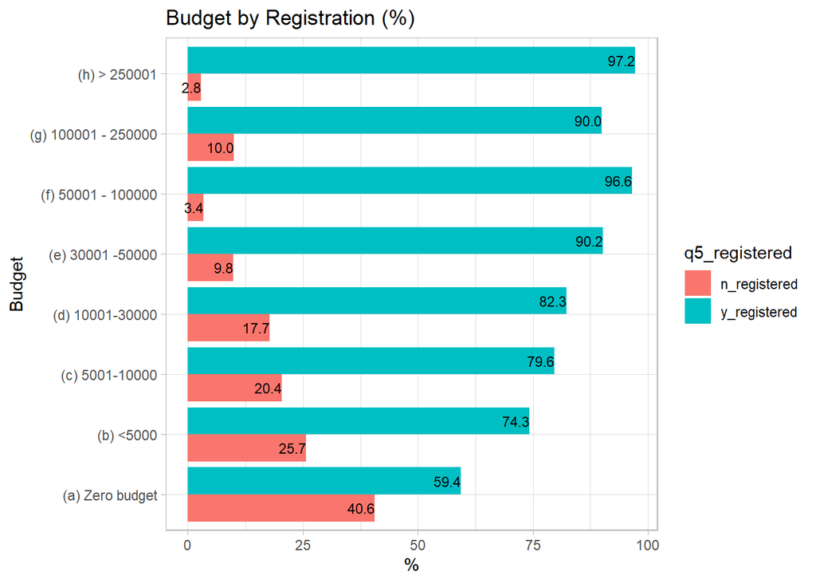

**-.-.-.-.-.-.-.-.-.-.-.-.-.-.-.-.-.-.-.-.-.-.-.-.-.-.-.-.-.-**

**Budget by Scope**

q10_budget_grp_2023

Diaspora

Global

Locally

Nationally

Regionally

Transnationally

1. Zero budget

9.1

11.9

16.9

8.7

4.1

15.8

2. <5000

18.2

8.5

22.2

12.8

4.1

15.8

3. 5001-10000

9.1

3.4

11.9

11.8

11.3

26.3

4. 10001-30000

9.1

8.5

18.4

15.5

13.4

5.3

5. 30001 -50000

NA

3.4

8.8

9.7

8.2

5.3

6. 50001 - 100000

18.2

8.5

9.4

13.6

19.6

5.3

7. 100001 - 250000

18.2

10.2

8.1

12.2

14.4

21.1

8. > 250001

18.2

45.8

4.4

15.9

24.7

5.3

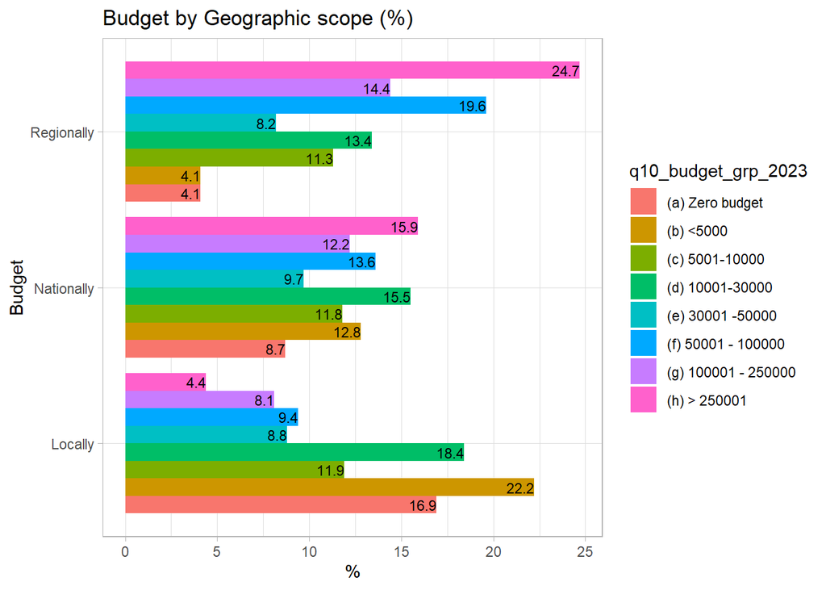

**-.-.-.-.-.-.-.-.-.-.-.-.-.-.-.-.-.-.-.-.-.-.-.-.-.-.-.-.-.-**

**Budget by Region**

This is only available for Nationally and Locally organisation because in the other cases they are multiple choice.

Region

Central Africa

Central America & Mexico

Caribbean

Central Asia & Caucasus

Eastern Europe, Southeast Europe and Central Europe

East Africa

East Asia

North Africa

North America

The Pacific

Southern Africa

South America

South Asia

Southeast Asia

South West Asia/Middle East

West Africa

Western Europe

1. Zero budget

7.8

13.3

11.1

11.1

9.5

9.2

11.1

40.0

10.5

25.0

21.4

11.2

7.3

19.6

7.7

9.8

9.1

2. <5000

10.9

9.3

14.8

11.1

NA

20.2

22.2

20.0

NA

18.8

19.0

13.3

19.1

19.6

19.2

26.8

13.6

3. 5001-10000

4.7

13.3

25.9

NA

14.3

11.8

NA

5.0

5.3

18.8

14.3

16.3

10.9

10.9

19.2

8.5

9.1

4. 10001-30000

31.2

24.0

NA

22.2

14.3

19.3

11.1

20.0

NA

NA

9.5

18.4

18.2

15.2

15.4

12.2

NA

5. 30001 -50000

6.2

6.7

7.4

11.1

4.8

10.1

NA

NA

21.1

12.5

2.4

9.2

12.7

8.7

11.5

12.2

13.6

6. 50001 - 100000

17.2

13.3

7.4

22.2

14.3

14.3

NA

NA

10.5

NA

9.5

7.1

17.3

4.3

7.7

13.4

18.2

7. 100001 - 250000

15.6

10.7

11.1

NA

14.3

10.9

33.3

5.0

26.3

6.2

9.5

5.1

10.9

13.0

7.7

8.5

9.1

8. > 250001

6.2

9.3

22.2

22.2

28.6

4.2

22.2

10.0

26.3

18.8

14.3

19.4

3.6

8.7

11.5

8.5

27.3

**-.-.-.-.-.-.-.-.-.-.-.-.-.-.-.-.-.-.-.-.-.-.-.-.-.-.-.-.-.-**

**Zero Budget by Region**

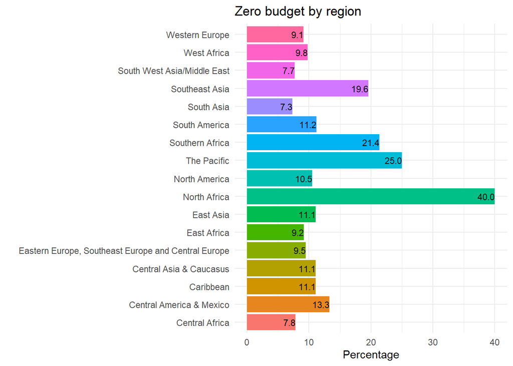

**-.-.-.-.-.-.-.-.-.-.-.-.-.-.-.-.-.-.-.-.-.-.-.-.-.-.-.-.-.-**

**Budget by year**

q10_budget_grp_2023

1. 2021-2023
2. From 2015 to 2020
3. From 2010 to 2014
4. From 2000 to 2009
5. Before 2000
1. Zero budget

25.7

13.2

8.1

4.5

4.3

2. <5000

30.9

17.8

13.4

8.0

2.1

3. 5001-10000

11.2

16.9

7.0

11.0

5.7

4. 10001-30000

13.8

16.0

21.5

11.5

14.9

5. 30001 -50000

5.9

8.9

9.9

11.0

6.4

6. 50001 - 100000

5.9

11.3

15.1

17.0

12.1

7. 100001 - 250000

3.9

9.5

12.2

14.0

17.7

8. > 250001

2.6

6.4

12.8

23.0

36.9

**-.-.-.-.-.-.-.-.-.-.-.-.-.-.-.-.-.-.-.-.-.-.-.-.-.-.-.-.-.-**

**COVID (Q11) by scope**

| q11_covid_incidence | diaspora_and_or_exile | globally_focused | locally_focused | nationally_focused | regionally_focused | transnationally_focused |
| --- | --- | --- | --- | --- | --- | --- |
| 1 Grow substantively | 12.5 | 4.3 | 7.7 | 4.7 | 8.8 | 7.7 |
| 2 Grow slightly | NA | 37.0 | 18.4 | 20.2 | 25.0 | NA |
| 3 Stay the same | 25.0 | 23.9 | 18.8 | 20.5 | 20.0 | 30.8 |
| 4 Decrease slightly | 25.0 | 21.7 | 24.8 | 23.4 | 26.2 | 15.4 |
| 5 Decrease substantially | 37.5 | 13.0 | 30.3 | 31.2 | 20.0 | 46.2 |

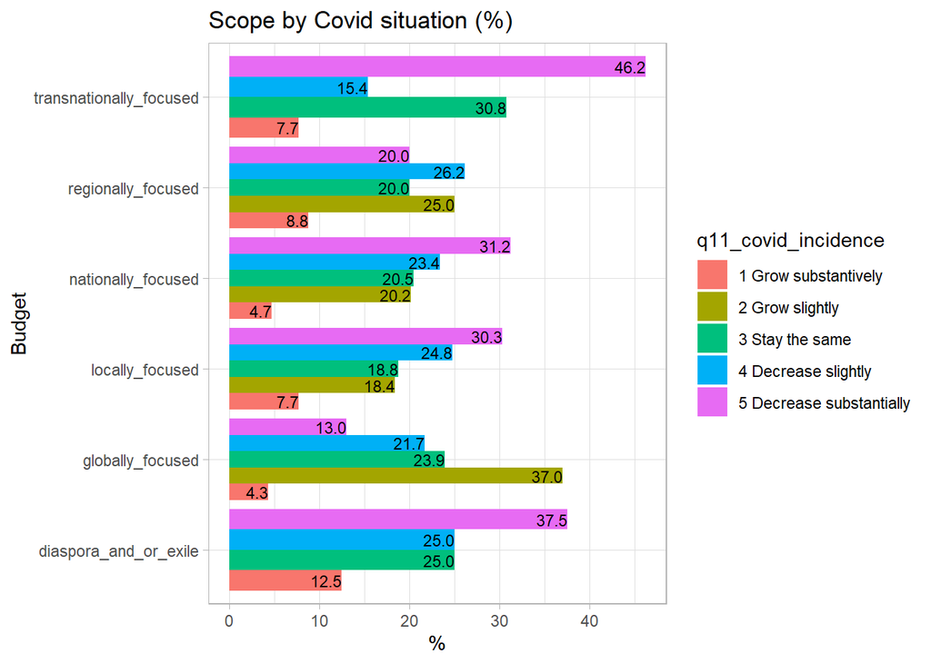